# Fires in the Paraná River Delta, Argentina

Natalia Morandeira (nmorandeira@unsam.edu.ar)

## Data source

This report is generated from the following zip files: **DL_FIRE_M6_189060.zip, DL_FIRE_V1_189061.zip** and a polygon of the study area.

The naming conventions of the FIRMS data are:

- DL_FIRE_M6.xx if you requested MODIS data (M6 stands for MODIS Collection 6), or
- DL_FIRE_V1.xx if you requested VIIRS 375m data from S-NPP.

Each of these zips has two shapefiles: recent and archive records.

## Summary results and plots

The number of VIIRS hotspots recorded during this year is **39821**, up to **2020-12-31**.

First, we’ll get a plot of the daily records. Spanish and English versions

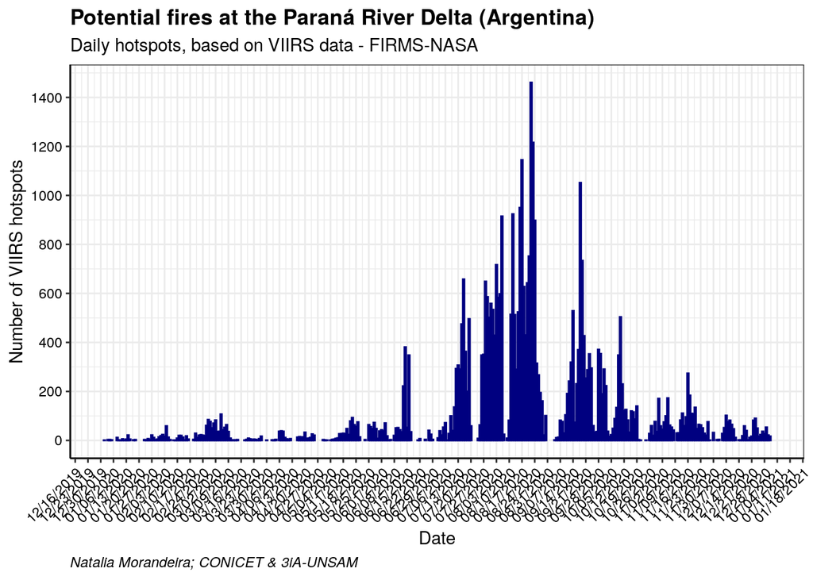

A plot of the cumulative hostspots. Spanish and English versions.

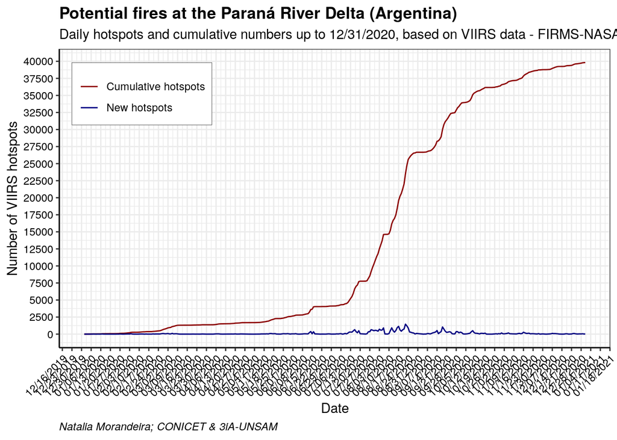

The next plot summarizes the number of VIIRS hotspots per month.

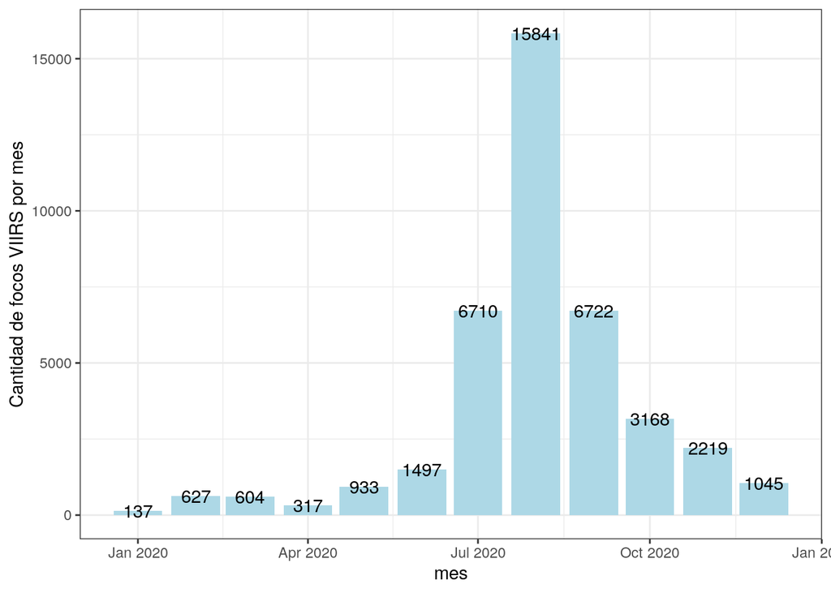

The month with the highest number of hotspots is August, with **15841** hotspots (**39.8%** % of the total hotspots up to **2020-12-31**).

While VIIRS data (resolution: 375 m) is available from 2012, MODIS data is available from 2001. However, MODIS resolution is 1 km, so fewer hotspots are reported and each hotspot corresponds to a greater area.

Now we compute and plot the number of MODIS hotspots per year.

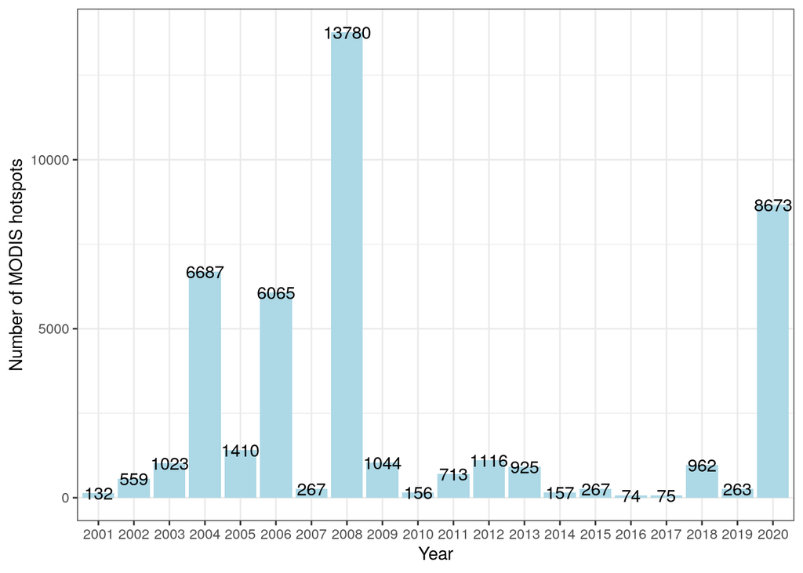

The cumulative number of MODIS hotspots during 2020 is **8673** up to **2020-12-31**, which is **62.9%** of the MODIS hotspots recorded during 2008.

Some plots summarizing the historical hotspots from MODIS data. Daily and monthly plots.

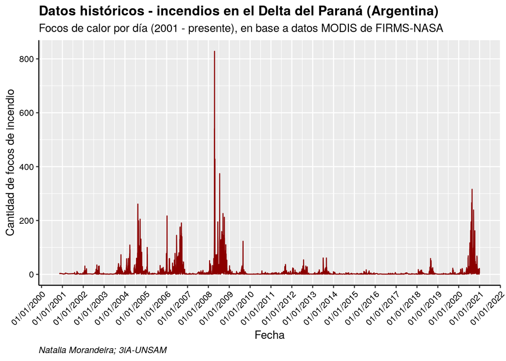

```
## Simple feature collection with 6 features and 2 fields
## Geometry type: MULTIPOINT
## Dimension:     XY
## Bounding box:  xmin: 5431559 ymin: 6220549 xmax: 5640738 ymax: 6479612
## CRS:           EPSG:5347
## # A tibble: 6 x 3
##   mes        cantidad_mes                                               geometry
##   <date>            <dbl>                                       <MULTIPOINT [m]>
## 1 2000-11-01            5 ((5464067 6359511), (5473032 6321065), (5569140 62556…
## 2 2001-01-01            5 ((5488228 6331211), (5489226 6331034), (5562212 62662…
## 3 2001-02-01            9 ((5567295 6261782), (5567501 6260715), (5585151 62429…
## 4 2001-04-01            2                 ((5596628 6220737), (5597631 6220549))
## 5 2001-07-01            3 ((5636164 6241319), (5637364 6241136), (5637537 62422…
## 6 2001-08-01           16 ((5431559 6479612), (5441331 6436601), (5441903 64372…
```

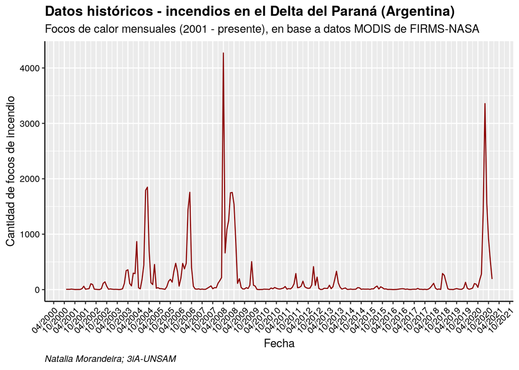

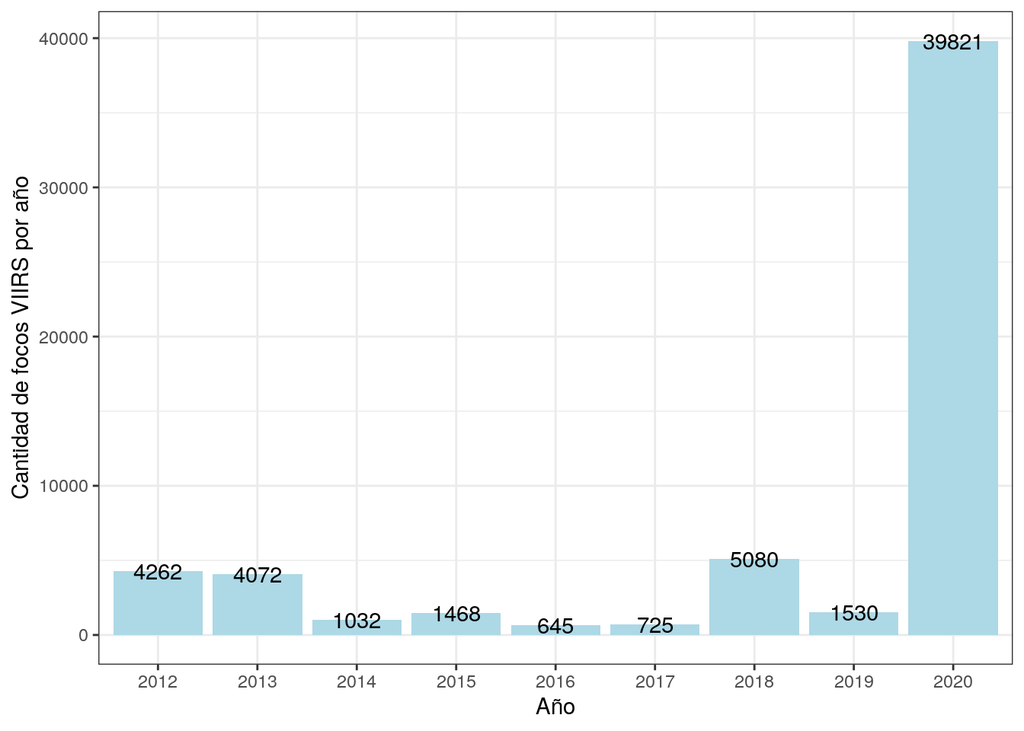

Lastly, we can comparte VIIRS and MODIS records.

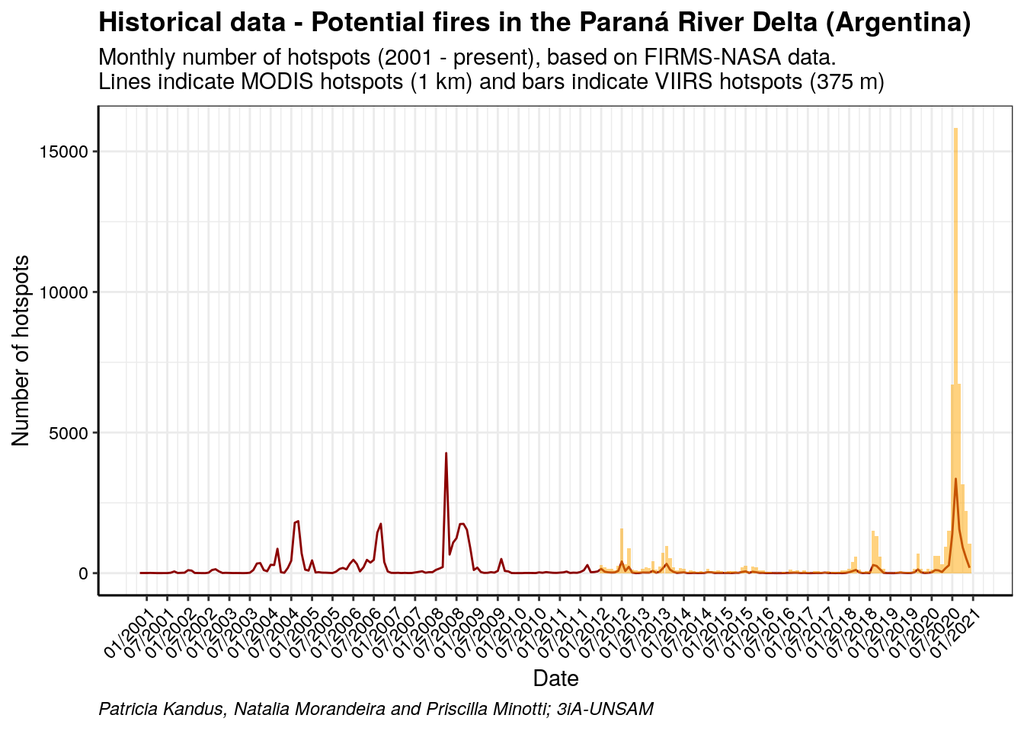

The plots are saved to the output folder.